# Airway : réponse à la dexaméthasone (GSE52778)

nf-core/rnaseq 3.27.0 (STAR + Salmon) puis DESeq2, comparé à Himes et al. 2014

```r
suppressPackageStartupMessages({
  library(tximport); library(DESeq2); library(tidyverse)
  library(pheatmap); library(EnhancedVolcano); library(ggrepel)
  library(clusterProfiler); library(org.Hs.eg.db)
})
theme_set(theme_bw(base_size = 12))
dir.create("../figures", showWarnings = FALSE)
```

# Problematique et référence

Quels gènes changent d’expression quand des cellules musculaires lisses des voies respiratoires humaines sont traitées à la dexaméthasone (un glucocorticoïde) ?

**Article de référence :** Himes BE *et al.*, *RNA-Seq Transcriptome Profiling Identifies CRISPLD2 as a Glucocorticoid Responsive Gene that Modulates Cytokine Function in Airway Smooth Muscle Cells*, PLoS ONE 2014;9(6):e99625 ([doi:10.1371/journal.pone.0099625](https://doi.org/10.1371/journal.pone.0099625)). Quatre lignées primaires d’ASM (donneurs masculins blancs), dexaméthasone 1 µM pendant 18 h, Illumina HiSeq 2000 en paires de 75 pb. Les auteurs ont aligné avec TopHat (hg19), quantifié avec Cufflinks et testé avec Cuffdiff (FDR < 0,05) : **316 gènes** différentiellement exprimés.

**Ce travail.** Mêmes données publiques (GSE52778), mais une chaîne moderne : STAR + Salmon sur GRCh38 / GENCODE v44 via nf-core/rnaseq, puis DESeq2 avec le design `~ cell + dex`.

# Import des comptages (tximport)

```r
meta <- read_csv("../metadata.csv", show_col_types = FALSE) |>
  mutate(dex = factor(dex, levels = c("untrt", "trt")),
         cell = factor(cell))

files <- file.path(params$salmon_dir, meta$sample, "quant.sf")
names(files) <- meta$sample
stopifnot(all(file.exists(files)))

tx2gene <- read_tsv(file.path(params$salmon_dir, "salmon.merged.tx2gene.tsv"),
                    show_col_types = FALSE)   # colonnes : transcript_id, gene_id, gene_name

txi <- tximport(files, type = "salmon", tx2gene = tx2gene[, c("transcript_id", "gene_id")],
                ignoreTxVersion = FALSE)
```

```
reading in files with read_tsv
```

```
1 2 3 4 5 6 7 8
summarizing abundance
summarizing counts
summarizing length
```

```r
gene_names <- distinct(tx2gene, gene_id, gene_name)
```

# DESeq2

Design `~ cell + dex` : la lignée cellulaire est une covariable de blocage. Les quatre donneurs ont des niveaux d’expression de base différents ; les modéliser revient à comparer chaque lignée traitée à sa propre version non traitée (test apparié). On retire ainsi la variabilité inter-donneur du bruit du test, ce qui augmente la puissance.

```r
coldata <- column_to_rownames(as.data.frame(meta), "sample")
stopifnot(identical(rownames(coldata), colnames(txi$counts)))
dds <- DESeqDataSetFromTximport(txi, colData = coldata, design = ~ cell + dex)
```

```
using counts and average transcript lengths from tximport
```

```r
dds <- dds[rowSums(counts(dds) >= 10) >= 3, ]     # gènes détectés (>= 10 comptages dans >= 3 échantillons)
dds <- DESeq(dds)
```

```
using 'avgTxLength' from assays(dds), correcting for library size
```

```r
res <- lfcShrink(dds, coef = "dex_trt_vs_untrt", type = "apeglm")
```

```
using 'apeglm' for LFC shrinkage. If used in published research, please cite:
    Zhu, A., Ibrahim, J.G., Love, M.I. (2018) Heavy-tailed prior distributions for
    sequence count data: removing the noise and preserving large differences.
    Bioinformatics. https://doi.org/10.1093/bioinformatics/bty895
```

```r
res_df <- as.data.frame(res) |>
  rownames_to_column("gene_id") |>
  left_join(gene_names, by = "gene_id") |>
  arrange(padj)
write_csv(res_df, "../results_deseq2.csv")

sig     <- res_df |> filter(!is.na(padj), padj < 0.05)
n_tested <- nrow(res_df)
n_sig    <- nrow(sig)
n_up     <- sum(sig$log2FoldChange > 0)
n_down   <- sum(sig$log2FoldChange < 0)
n_sig_l1 <- sum(abs(sig$log2FoldChange) > 1)
summary(res, alpha = 0.05)
```

```
out of 16380 with nonzero total read count
adjusted p-value < 0.05
LFC > 0 (up)       : 1950, 12%
LFC < 0 (down)     : 1637, 10%
outliers [1]       : 0, 0%
low counts [2]     : 318, 1.9%
(mean count < 9)
[1] see 'cooksCutoff' argument of ?results
[2] see 'independentFiltering' argument of ?results
```

**Bilan.** Sur **16 380** gènes testés, **3 587** sont significatifs à padj < 0,05 (**1950** induits, **1637** réprimés), dont **767** avec un |log2FC| > 1. Les log2FC sont *rétrécis* par `apeglm` : ils sont prudents pour les gènes peu exprimés, ce qui explique l’absence des fold changes extrêmes artificiels qu’on voit avec les estimations brutes.

# 1. Contrôles qualité des échantillons

## 1.1 PCA

```r
vsd <- vst(dds, blind = FALSE)

pca_df <- function(obj) {
  d <- plotPCA(obj, intgroup = c("dex", "cell"), returnData = TRUE)
  attr(d, "pv") <- round(100 * attr(d, "percentVar"))
  d
}
plot_pca <- function(d, titre) {
  pv <- attr(d, "pv")
  ggplot(d, aes(PC1, PC2, colour = dex, shape = cell)) +
    geom_path(data = arrange(d, cell, dex), aes(group = cell), colour = "grey55",
              linewidth = 0.4, arrow = arrow(length = unit(2.5, "mm"), type = "closed")) +
    geom_point(size = 4) +
    geom_text_repel(aes(label = cell), size = 3, show.legend = FALSE, colour = "grey25",
                    box.padding = 0.4, min.segment.length = Inf) +
    scale_colour_manual(values = c(untrt = "#3B6FB6", trt = "#D9541E"),
                        labels = c(untrt = "Contrôle", trt = "Dexaméthasone"), name = "Traitement") +
    labs(title = titre, x = paste0("PC1 : ", pv[1], " % de variance"),
         y = paste0("PC2 : ", pv[2], " % de variance"), shape = "Lignée",
         caption = "Flèche : de la condition contrôle vers la condition traitée, pour une même lignée")
}

d1 <- pca_df(vsd)
```

```
using ntop=500 top features by variance
```

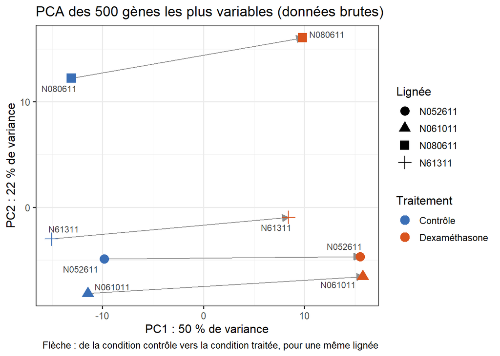

```r
p1 <- plot_pca(d1, "PCA des 500 gènes les plus variables (données brutes)")
ggsave("../figures/pca.png", p1, width = 7.5, height = 5.2, dpi = 200)
p1
```

```r
# Même PCA après retrait de l'effet de la lignée (pour visualiser l'effet du traitement seul)
vsd_nb <- vsd
assay(vsd_nb) <- limma::removeBatchEffect(assay(vsd), batch = vsd$cell)
d2 <- pca_df(vsd_nb)
```

```
using ntop=500 top features by variance
```

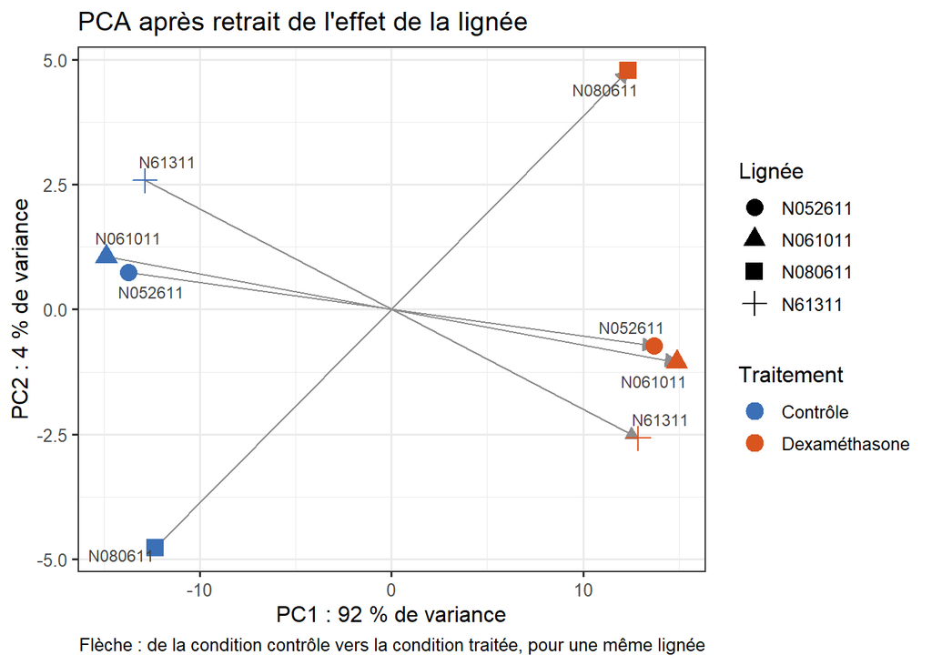

```r
p2 <- plot_pca(d2, "PCA après retrait de l'effet de la lignée")
ggsave("../figures/pca_sans_lignee.png", p2, width = 7.5, height = 5.2, dpi = 200)
p2
```

**Analyse** La première composante (PC1, 50 % de la variance) sépare les échantillons traités des échantillons contrôles, sans chevauchement. La deuxième (PC2, 22 %) sépare surtout la lignée `N080611` des trois autres. Les flèches, qui relient chaque lignée entre ses deux conditions, vont toutes dans le même sens sur PC1.

**Interprétation.**

Point de comparaison avec l’article : Himes *et al.* soulignent une **variabilité notable entre donneurs** (ils le citent comme limite). Elle apparaît ici directement sur PC2.

## 1.2 Distance entre échantillons

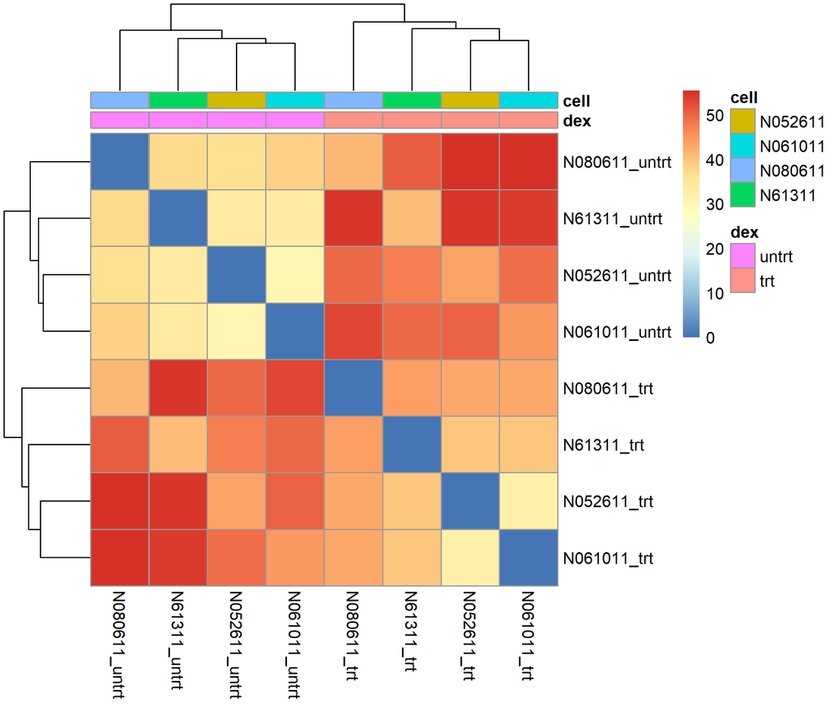

```r
d <- dist(t(assay(vsd)))
ann <- as.data.frame(colData(vsd)[, c("dex", "cell")])
pheatmap(as.matrix(d), clustering_distance_rows = d, clustering_distance_cols = d,
         annotation_col = ann,
         filename = "../figures/sample_clustering.png", width = 7, height = 6)
knitr::include_graphics("../figures/sample_clustering.png")
```

**Analyse** Matrice des distances euclidiennes entre échantillons (sur les données stabilisées). Bleu = proches, rouge = éloignés. Le dendrogramme coupe les 8 échantillons en deux grands groupes : les 4 contrôles et les 4 traités.

**Interprétation :**

- Aucun échantillon ne se range dans le mauvais groupe : pas d’inversion d’étiquettes ni d’échantillon aberrant.
- Les **contrôles sont plus homogènes entre eux que les traités** (distances plus faibles dans le bloc contrôle). La dexaméthasone ne déplace donc pas tous les donneurs de la même façon, ce qui recoupe l’image de la PCA.
- `N080611_untrt` est le contrôle le plus éloigné des trois autres : c’est la même lignée que celle qui se détache sur PC2.

Dans le rapport MultiQC du pipeline (`results_slurm/multiqc/star_salmon/multiqc_report.html`), la PCA et le clustering calculés sur les comptages Salmon donnent la même image.

# 2. Résultats d’expression différentielle

## 2.1 Volcan

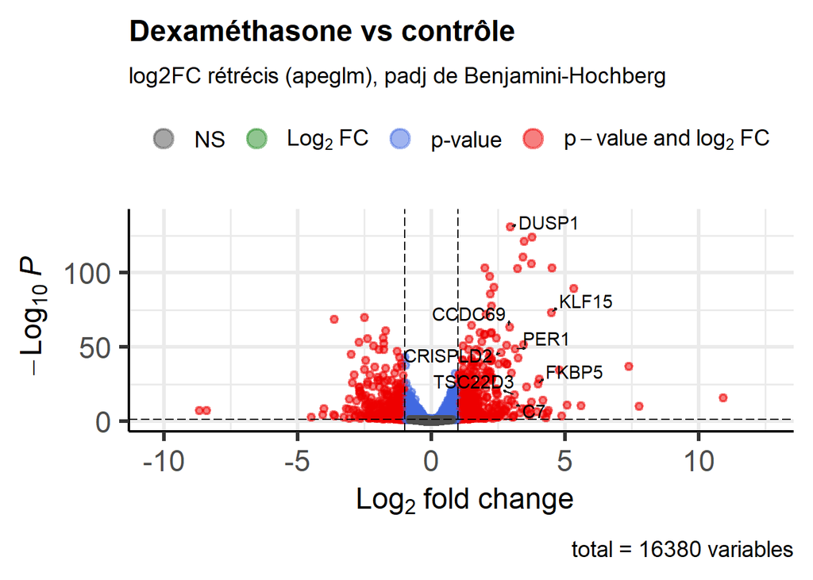

```r
etiq <- c("DUSP1", "KLF15", "PER1", "TSC22D3", "FKBP5", "CRISPLD2", "C7", "CCDC69")
p <- EnhancedVolcano(res_df, lab = res_df$gene_name, x = "log2FoldChange", y = "padj",
                     pCutoff = 0.05, FCcutoff = 1, title = "Dexaméthasone vs contrôle",
                     subtitle = "log2FC rétrécis (apeglm), padj de Benjamini-Hochberg",
                     selectLab = etiq, drawConnectors = TRUE, max.overlaps = Inf,
                     labSize = 4, pointSize = 1.5)
ggsave("../figures/volcano.png", p, width = 8, height = 7, dpi = 200)
p
```

**Analyse** Chaque point est un gène. En abscisse, le log2 du changement d’expression (positif = induit par la dexaméthasone) ; en ordonnée, la significativité (−log10 de la p ajustée). Rouge : padj < 0,05 **et** |log2FC| > 1.

**Interprétation**

- Le nuage est **asymétrique** : les gènes les plus fortement induits (à droite) sont aussi les plus significatifs, avec `DUSP1` en tête de classement. La réponse transcriptionnelle à un glucocorticoïde est avant tout une **activation** de gènes, via le récepteur GR.
- Il y a cependant **beaucoup de gènes réprimés** (à gauche), avec une significativité élevée : la dexaméthasone ne fait pas qu’allumer des gènes.
- Les gènes de contrôle de l’article (`DUSP1`, `KLF15`, `PER1`, `TSC22D3`, `FKBP5`) sont bien dans le lot des gènes induits et significatifs. Les gènes nouveaux mis en avant par les auteurs (`CRISPLD2`, `C7`, `CCDC69`) le sont aussi.
- Quelques points isolés ont un changement extrême : `ALOX15B` (log2FC ≈ +11, expression moyenne faible, ≈ 65 comptages), `ZBTB16` (≈ +7, bien exprimé, ≈ 1 200 comptages), ainsi que deux transcrits peu exprimés vers −8 (`KBTBD11-OT1` et un gène non annoté). Pour les gènes peu exprimés, un rapport aussi grand repose sur très peu de lectures et reste à confirmer ; `ZBTB16`, bien détecté, est en revanche un signal robuste.

## 2.2 Les gènes les plus différentiels

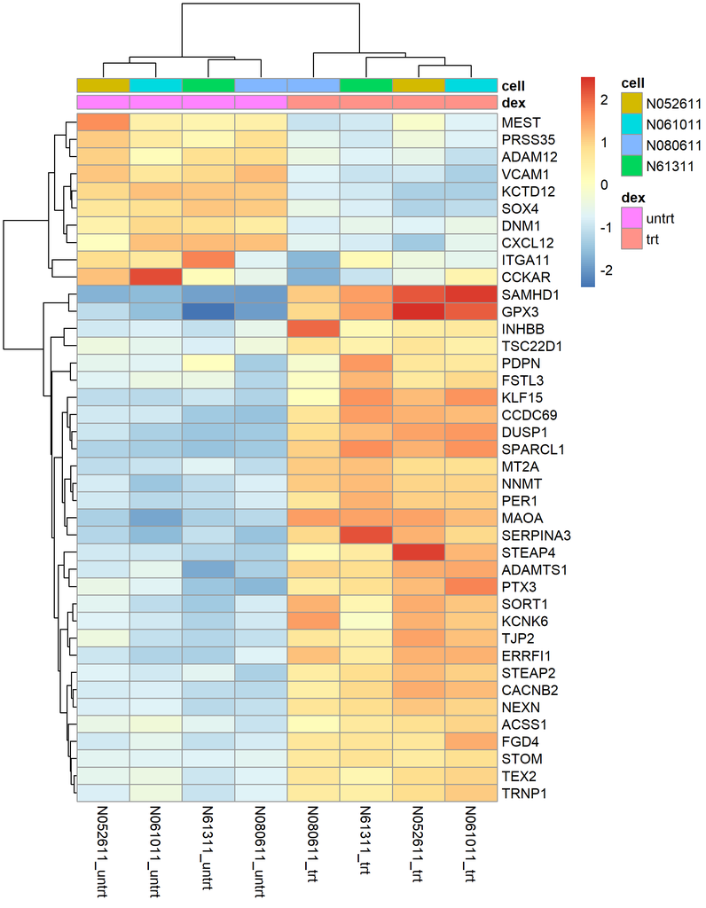

```r
top <- res_df |> filter(!is.na(padj)) |> slice_head(n = 40)
mat <- assay(vsd)[top$gene_id, ]
rownames(mat) <- make.unique(top$gene_name)
mat <- mat - rowMeans(mat)
pheatmap(mat, annotation_col = ann,
         filename = "../figures/heatmap_top40.png", width = 7, height = 9)
knitr::include_graphics("../figures/heatmap_top40.png")
```

**Analyse** Expression (centrée par gène) des 40 gènes les plus significatifs. Chaque colonne est un échantillon. Les colonnes se regroupent **d’elles-mêmes** en contrôles et traités ; les lignes se séparent en deux blocs.

**Interprétation**

- Un grand bloc de gènes **induits** (rouge chez les traités) : entre autres `SAMHD1`, `GPX3`, `KLF15`, `DUSP1`, `SPARCL1`, `PER1`, `MAOA`, `STEAP4`, `SERPINA3`, `ADAMTS1`, `PTX3`, `CACNB2`. Les quatre donneurs répondent dans le **même sens**, avec des intensités un peu différentes.
- Un petit bloc de gènes **réprimés** (haut de la figure) : `VCAM1`, `CXCL12`, `SOX4`, `ADAM12`, `MEST`, `ITGA11`, `KCTD12`. La répression de molécules d’adhésion et de chimiokines va dans le sens d’un effet anti-inflammatoire de la dexaméthasone, sans que je l’aie vérifié gène par gène dans la littérature.
- Dans le groupe des traités, `N080611_trt` se place un peu à part, comme sur la PCA.

# 3. Comparaison quantitative avec l’article

Les auteurs ont validé par qPCR huit gènes (cinq connus, trois nouveaux) et en donnent les FPKM moyens sans puis avec dexaméthasone. Le rapport des deux donne un fold change qu’on peut comparer aux nôtres.

```r
# FPKM moyens (contrôle, dexaméthasone) relevés dans Himes et al. 2014 : à revérifier dans l'article.
art <- tribble(
  ~gene_name, ~fpkm_ctrl, ~fpkm_dex,
  "DUSP1",    18.26, 144.96,
  "FKBP5",     3.43,  53.05,
  "KLF15",     0.86,  20.46,
  "PER1",      1.49,  13.69,
  "TSC22D3",   9.69,  93.26,
  "CRISPLD2",  7.89,  51.17,
  "C7",        3.76,  38.41,
  "CCDC69",    6.24,  47.39
) |> mutate(fc_article = fpkm_dex / fpkm_ctrl)

cmp <- art |>
  left_join(res_df |> dplyr::select(gene_name, log2FoldChange, padj), by = "gene_name") |>
  mutate(fc_ici = 2^log2FoldChange,
         rapport = fc_ici / fc_article)

cmp |> transmute(Gène = gene_name,
                 `FC article (FPKM)` = round(fc_article, 1),
                 `FC ici (DESeq2)` = round(fc_ici, 1),
                 `padj ici` = signif(padj, 2)) |>
  knitr::kable()
```

| Gène | FC article (FPKM) | FC ici (DESeq2) | padj ici |
| --- | --- | --- | --- |
| DUSP1 | 7.9 | 7.8 | 0 |
| FKBP5 | 15.5 | 15.9 | 0 |
| KLF15 | 23.8 | 22.4 | 0 |
| PER1 | 9.2 | 8.8 | 0 |
| TSC22D3 | 9.6 | 8.6 | 0 |
| CRISPLD2 | 6.5 | 6.1 | 0 |
| C7 | 10.2 | 8.6 | 0 |
| CCDC69 | 7.6 | 7.5 | 0 |

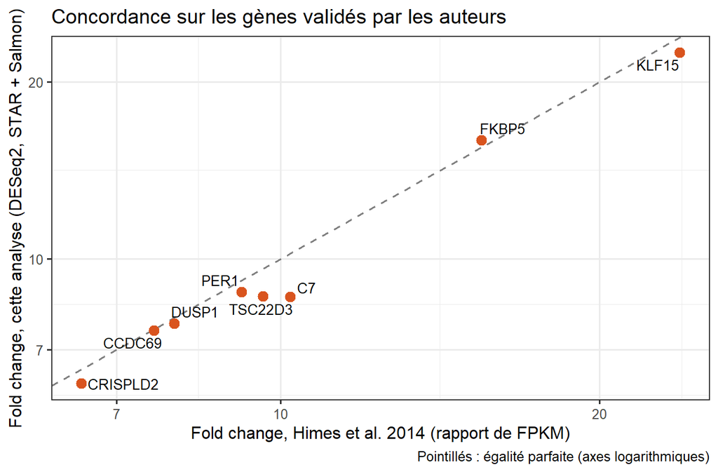

```r
p <- ggplot(cmp, aes(fc_article, fc_ici, label = gene_name)) +
  geom_abline(slope = 1, intercept = 0, linetype = 2, colour = "grey50") +
  geom_point(size = 3, colour = "#D9541E") +
  geom_text_repel(size = 3.5) +
  scale_x_log10() + scale_y_log10() +
  labs(x = "Fold change, Himes et al. 2014 (rapport de FPKM)",
       y = "Fold change, cette analyse (DESeq2, STAR + Salmon)",
       title = "Concordance sur les gènes validés par les auteurs",
       caption = "Pointillés : égalité parfaite (axes logarithmiques)")
ggsave("../figures/comparaison_article.png", p, width = 7, height = 5, dpi = 200)
p
```

**Analyse** Chaque point est l’un des huit gènes validés. Sur la diagonale en pointillés, l’analyse reproduit exactement le fold change publié.

**Interprétation**

- Les **huit gènes sont retrouvés, tous induits et très significatifs** (padj < 1e-11). La quasi-totalité des points tombe près de la diagonale. Sur `DUSP1`, `PER1`, `CRISPLD2`, `CCDC69`, `TSC22D3`, `KLF15`, le fold change est à quelques dizaines de pourcents de la valeur publiée.
- Les écarts les plus nets sont sur `C7` et `TSC22D3` (un peu plus faibles ici) ; ils restent modestes. Pour les gènes peu exprimés à l’état basal, un FPKM moyen n’est pas directement comparable à un log2FC rétréci, donc je n’en tire pas de conclusion.
- **`CRISPLD2`**, le gène mis en avant par les auteurs, est retrouvé avec un fold change d’environ 6 (6,5 dans l’article) et un padj de l’ordre de 1e-47. Ce résultat central de la publication est reproduit.

Cette concordance sur des gènes validés expérimentalement est le meilleur argument que la chaîne d’analyse est correcte, malgré des outils différents (STAR/Salmon/DESeq2 contre TopHat/Cufflinks/Cuffdiff) et un génome différent (GRCh38 contre hg19).

## Différences de méthode

|  | Himes *et al.* 2014 | Cette analyse |
| --- | --- | --- |
| Génome / annotation | hg19, RefSeq | GRCh38, GENCODE v44 |
| Alignement | TopHat 2.0.4 | STAR (via nf-core/rnaseq 3.27.0) |
| Quantification | Cufflinks (FPKM) | Salmon, agrégé au gène avec tximport |
| Test | Cuffdiff, FDR < 0,05 | DESeq2 `~ cell + dex`, padj < 0,05 |
| Gènes significatifs | 316 | 3 587 |

Pourquoi 316 contre 3 587 ? hypothèse : DESeq2 avec le donneur comme covariable est plus puissant qu’un test qui ne modélise pas l’appariement ; Cuffdiff est connu pour être conservateur avec peu de réplicats ; les annotations (RefSeq contre GENCODE) et les filtres diffèrent. Cependant, **les gènes forts et validés sont les mêmes**.